# Survival Analysis

Eva Freyhult

NBIS, SciLifeLab

September 10, 2026

## Survival analysis

Statistical methods for **time-to-event data**

- Originally applied to time until death in mortality studies
- Now widely used in many fields:
  - Medicine: time to relapse
  - Marketing: time to next purchase
  - Engineering: time to failure
  - Criminology: time to reoffend

**Key feature:** the outcome is time until an event, often with **censoring**.

Survival analysis is not limited to calendar time, it can also be applied to for example:

- Number of treatment sessions until recovery
- Number of attempts until passing an exam

## Survival and censoring times

Let’s imagine:

- a mortality study of terminally ill patients receiving a medical treatment.
- a follow-up period of **24 months**
- the outcome of interest is **time until death**
- for each patient, we record the **time until death or censoring**

## Survival and censoring times

For each patient, we suppose there is:

- a true **survival time** $T$
- a **censoring time** $C$

We observe the **random variable**
$$Y = \min (T, C)$$

- If $T \leq C$, we observe the event time $T$
- If $T > C$, we observe the censoring time $C$

and an event indicator

$$\delta =
\left\{
\begin{array}{cc}
1 & \mathrm{if\ } T \le C \\
0 & \mathrm{if\ } T>C \\
\end{array}
\right.$$

## Survival and censoring times

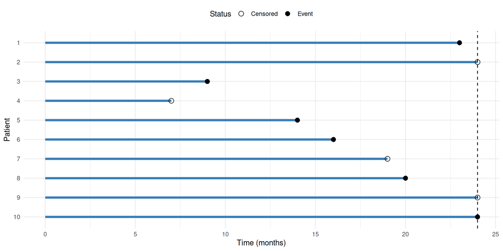

Figure 1: Example of right-censored data in a mortality study lasting 24 months. The horizontal lines represent the time to event or censoring for each patient. The points indicate whether the event occurred (event) or not (censored).

- For patient 1: $(y_1 = t_1 = 23, \delta_1 = 1)$
- For patient 2: $(y_2 = c_2 = 24, \delta_2 = 0)$
- For patient 4: $(y_4 = c_4 = 7, \delta_4 = 0)$, a patient lost to follow-up

## Independent Censoring

To analyze survival data correctly, we assume **independent censoring**:

- the reason for censoring is unrelated to the risk of the event
- censored individuals are assumed to have the same event risk as those still under observation

**Example**

- ✅ Patients leave a cancer study for unrelated reasons, e.g. moving away
- ❌ Patients drop out because they are very sick

## Left and interval censoring

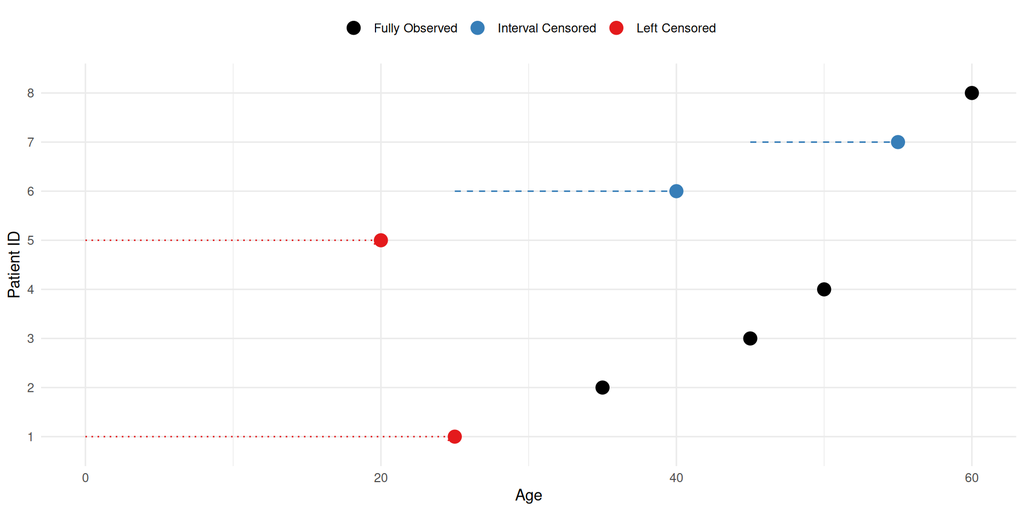

Figure 2: Example of left and interval censoring in an age study. Left-censored patients were diagnosed before the study, and interval-censored patients were diagnosed between visits.

In this lecture, we focus on **right-censored** data.

## Kaplan-Meier estimator

The **survival function** is

$$S(t) = P(T > t)$$

the probability of surviving past time $t$.

The **Kaplan-Meier (KM) estimator** is
$$\hat{S}(t) = \prod_{t_j \le t} \left( 1 - \frac{d_j}{n_j} \right)$$

where:

- $d_j$: number of events at time $t_j$
- $n_j$: number at risk just before time $t_j$

The Kaplan-Meier estimator is also called the **product-limit estimator**.

## Tooth filling example

*Complete follow-up*

Suppose 10 patients receive a tooth filling, and we record the time until failure.

| patientID | time | status |
| --- | --- | --- |
| 1 | 10 | 1 |
| 2 | 8 | 1 |
| 3 | 11 | 1 |
| 4 | 5 | 1 |
| 5 | 4 | 1 |
| 6 | 3 | 1 |
| 7 | 7 | 1 |
| 8 | 6 | 1 |
| 9 | 12 | 1 |
| 10 | 8 | 1 |

$\Longrightarrow$

sort

| patientID | time | status |
| --- | --- | --- |
| 6 | 3 | 1 |
| 5 | 4 | 1 |
| 4 | 5 | 1 |
| 8 | 6 | 1 |
| 7 | 7 | 1 |
| 2 | 8 | 1 |
| 10 | 8 | 1 |
| 1 | 10 | 1 |
| 3 | 11 | 1 |
| 9 | 12 | 1 |

Goal:

- estimate the probability that a filling remains intact over time
- first assume **complete follow-up**, i.e. no censoring

## Tooth filling example

*Building the Kaplan-Meier table*

- the number at risk, $n_j$
- the number of events, $d_j$
- the conditional survival, $1-\frac{d_j}{n_j}$
- $S(t) = \prod_{t_j \le t} \left( 1 - \frac{d_j}{n_j} \right)$

Sorted data

| Patient | Time | Status |
| --- | --- | --- |
| 6 | 3 | 1 |
| 5 | 4 | 1 |
| 4 | 5 | 1 |
| 8 | 6 | 1 |
| 7 | 7 | 1 |
| 2 | 8 | 1 |
| 10 | 8 | 1 |
| 1 | 10 | 1 |
| 3 | 11 | 1 |
| 9 | 12 | 1 |

| Time | At risk $n_j$ | Events $d_j$ | Conditional survival | Cumulative survival |
| --- | --- | --- | --- | --- |
| 3 | 10 | 1 | $1-\frac{1}{10} = 0.9$ | $0.9$ |
| 4 |  |  |  |  |
| 5 |  |  |  |  |
| 6 |  |  |  |  |
| 7 |  |  |  |  |
| 8 |  |  |  |  |
| 10 |  |  |  |  |
| 11 |  |  |  |  |
| 12 |  |  |  |  |

| Time | At risk $n_j$ | Events $d_j$ | Conditional survival | Cumulative survival |
| --- | --- | --- | --- | --- |
| 3 | 10 | 1 | $0.9$ | $0.9$ |
| 4 | 9 | 1 | $1-\frac{1}{9} = 0.888$ | $0.9 \times 0.888$ |
| 5 |  |  |  |  |
| 6 |  |  |  |  |
| 7 |  |  |  |  |
| 8 |  |  |  |  |
| 10 |  |  |  |  |
| 11 |  |  |  |  |
| 12 |  |  |  |  |

| Time | At risk $n_j$ | Events $d_j$ | Conditional survival | Cumulative survival |
| --- | --- | --- | --- | --- |
| 3 | 10 | 1 | $0.9$ | $0.9$ |
| 4 | 9 | 1 | $0.888$ | $0.8$ |
| 5 | 8 | 1 | $1-\frac{1}{8} = 0.875$ | $0.8 \times 0.875$ |
| 6 |  |  |  |  |
| 7 |  |  |  |  |
| 8 |  |  |  |  |
| 10 |  |  |  |  |
| 11 |  |  |  |  |
| 12 |  |  |  |  |

| Time | At risk $n_j$ | Events $d_j$ | Conditional survival | Cumulative survival |
| --- | --- | --- | --- | --- |
| 3 | 10 | 1 | $0.9$ | $0.9$ |
| 4 | 9 | 1 | $0.888$ | $0.8$ |
| 5 | 8 | 1 | $0.875$ | $0.7$ |
| 6 | 7 | 1 | $0.857$ | $0.6$ |
| 7 | 6 | 1 | $0.833$ | $0.5$ |
| 8 | 5 | 2 | $0.6$ | $0.3$ |
| 10 | 3 | 1 | $0.667$ | $0.2$ |
| 11 | 2 | 1 | $0.5$ | $0.1$ |
| 12 | 1 | 1 | $0$ | $0$ |

## Kaplan-Meier curve

The Kaplan-Meier curve shows the cumulative survival probabilities.

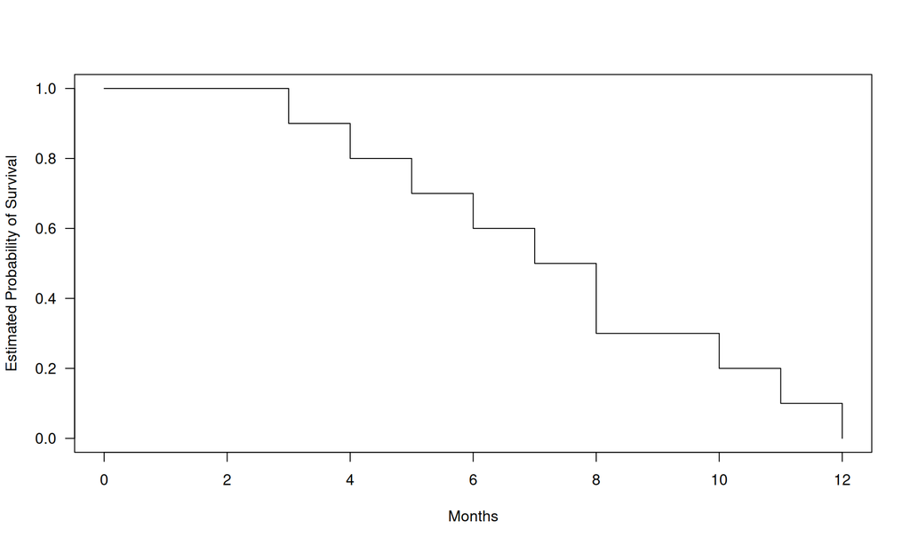

Figure 3: Kaplan-Meier curve for tooth filling data with complete follow-up.

## Tooth filling example

*What changes with censoring?*

Now suppose two patients are censored.

- censored patients remain in the **risk set** until censoring
- they do **not** count as events
- censoring affects future risk sets, but does not change survival at the censoring time

Sorted data with censoring

| Patient | Time | Status |
| --- | --- | --- |
| 6 | 3 | 1 |
| 5 | 4 | 1 |
| 4 | 5 | 0 |
| 8 | 6 | 1 |
| 7 | 7 | 1 |
| 2 | 8 | 1 |
| 10 | 8 | 1 |
| 1 | 10 | 0 |
| 3 | 11 | 1 |
| 9 | 12 | 1 |

## Tooth filling example

*What changes with censoring?*

Now suppose two patients are censored.

Sorted data with censoring

| Patient | Time | Status |
| --- | --- | --- |
| 6 | 3 | 1 |
| 5 | 4 | 1 |
| 4 | 5 | 0 |
| 8 | 6 | 1 |
| 7 | 7 | 1 |
| 2 | 8 | 1 |
| 10 | 8 | 1 |
| 1 | 10 | 0 |
| 3 | 11 | 1 |
| 9 | 12 | 1 |

| Time | At risk $n_j$ | Events $d_j$ | Censored | Conditional survival | Cumulative survival |
| --- | --- | --- | --- | --- | --- |
| 3 | 10 | 1 | 0 | $1-\frac{1}{10} = 0.9$ | $0.9$ |
| 4 |  |  |  |  |  |
| 5 |  |  |  |  |  |
| 6 |  |  |  |  |  |
| 7 |  |  |  |  |  |
| 8 |  |  |  |  |  |
| 10 |  |  |  |  |  |
| 11 |  |  |  |  |  |
| 12 |  |  |  |  |  |

| Time | At risk $n_j$ | Events $d_j$ | Censored | Conditional survival | Cumulative survival |
| --- | --- | --- | --- | --- | --- |
| 3 | 10 | 1 | 0 | $0.9$ | $0.9$ |
| 4 | 9 | 1 | 0 | $1-\frac{1}{9} = 0.888$ | $0.9 \times 0.888$ |
| 5 |  |  |  |  |  |
| 6 |  |  |  |  |  |
| 7 |  |  |  |  |  |
| 8 |  |  |  |  |  |
| 10 |  |  |  |  |  |
| 11 |  |  |  |  |  |
| 12 |  |  |  |  |  |

| Time | At risk $n_j$ | Events $d_j$ | Censored | Conditional survival | Cumulative survival |
| --- | --- | --- | --- | --- | --- |
| 3 | 10 | 1 | 0 | $0.9$ | $0.9$ |
| 4 | 9 | 1 | 0 | $0.888$ | $0.8$ |
| 5 | 8 | 0 | 1 |  | $0.8$ |
| 6 |  |  |  |  |  |
| 7 |  |  |  |  |  |
| 8 |  |  |  |  |  |
| 10 |  |  |  |  |  |
| 11 |  |  |  |  |  |
| 12 |  |  |  |  |  |

| Time | At risk $n_j$ | Events $d_j$ | Censored | Conditional survival | Cumulative survival |
| --- | --- | --- | --- | --- | --- |
| 3 | 10 | 1 | 0 | $0.9$ | $0.9$ |
| 4 | 9 | 1 | 0 | $0.888$ | $0.8$ |
| 5 | 8 | 0 | 1 |  | $0.8$ |
| 6 | 7 | 1 | 0 | $0.857$ | $0.686$ |
| 7 | 6 | 1 | 0 | $0.833$ | $0.571$ |
| 8 | 5 | 2 | 0 | $0.6$ | $0.343$ |
| 10 | 3 | 0 | 1 |  | $0.343$ |
| 11 | 2 | 1 | 0 | $0.5$ | $0.171$ |
| 12 | 1 | 1 | 0 | $0$ | $0$ |

## Kaplan-Meier curve

The Kaplan-Meier curve shows the cumulative survival probabilities.

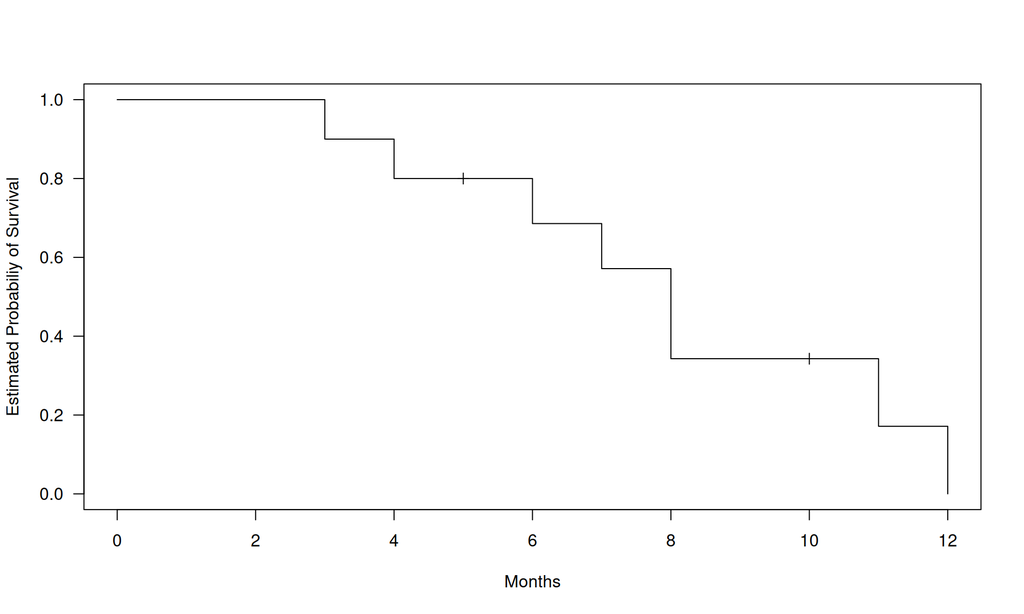

Figure 4: Kaplan-Meier survival curve for tooth filling data. The curve shows the estimated probability of survival (filling intact) over time.

## Kaplan-Meier estimator

*Reading a survival probability from the curve*

Example: what is the probability that a tooth filling lasts at least **10 months**?

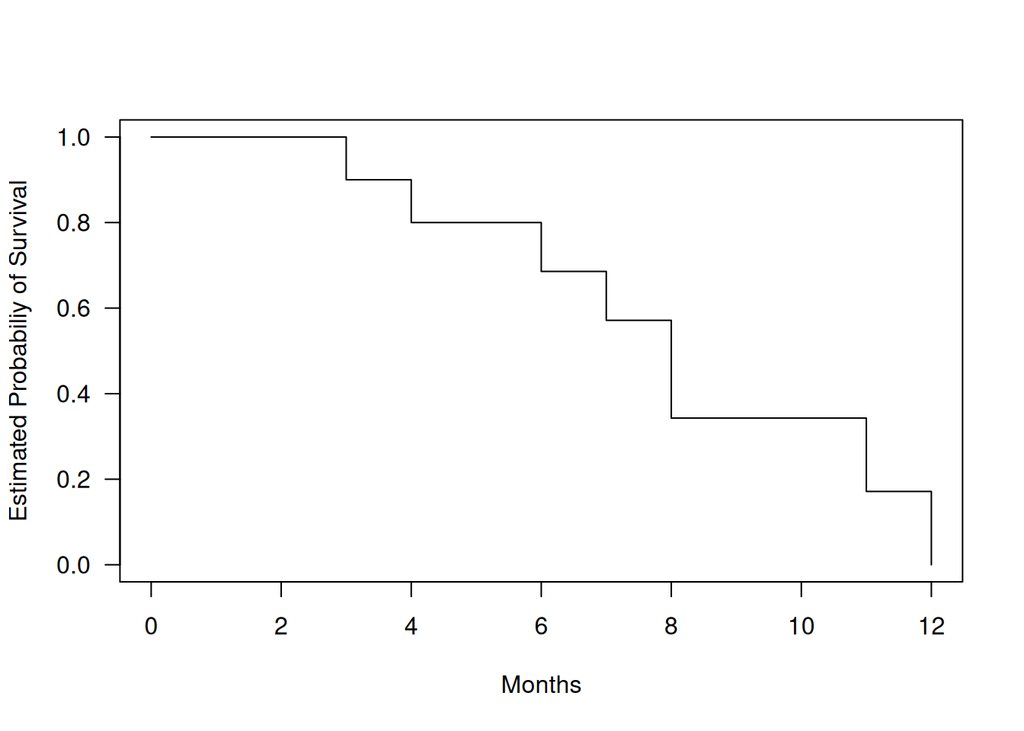

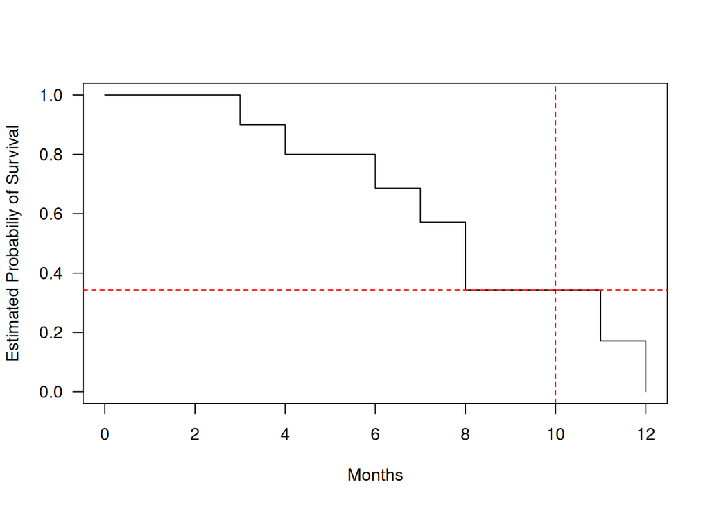

## Comparison of survival

When comparing survival between groups, we often start by plotting **Kaplan-Meier curves**.

- These curves show how the **survival probability** changes over time in each group.
- If the curves are close together, the groups may have similar survival experiences.
- If the curves are clearly separated, this suggests a difference in survival.
- If the curves cross, the difference may change over time and interpretation becomes more difficult.

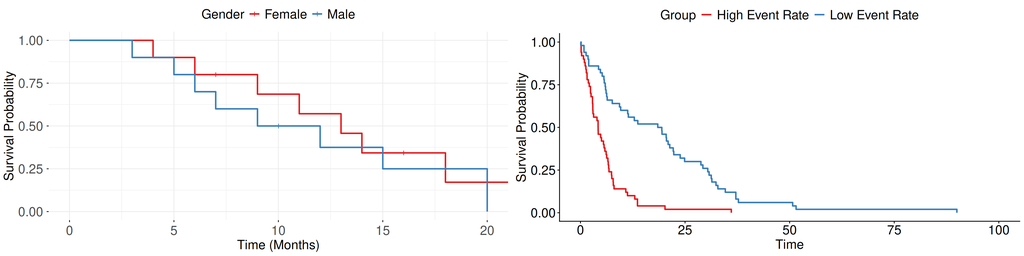

## Mantel-Cox (log-rank test)

The **log-rank test** compares survival between two or more groups.

- Null hypothesis: no difference in survival between groups
- At each event time, compare the **observed** and **expected** number of events
- Combine these differences over all event times
- Test statistic follows a **chi-square distribution**

## Mantel-Cox (log-rank test)

At a given event time:

|  | Died | Survived | Total at risk |
| --- | --- | --- | --- |
| Group A | $d_{jA}$ | $r_{jA}$ | $n_{jA}$ |
| Group B | $d_{jB}$ | $r_{jB}$ | $n_{jB}$ |
| Total | $d_j$ | $r_j$ | $n_j$ |

Observed number of events at time $t_j$:

$$O_{jA} = d_{jA}, \qquad O_{jB} = d_{jB}$$

Expected number of events at time $t_j$:

$$E_{jA} = \frac{n_{jA} d_j}{n_j}, \qquad
E_{jB} = \frac{n_{jB} d_j}{n_j}$$

Large differences between **observed** and **expected** numbers of events give evidence against the null hypothesis.

## Mantel-Cox (log-rank test)

The Mantel-Cox (log-rank) statistic combines the observed-minus-expected differences over all event times:

$$\chi^2_{MC} = \sum_{j} \left( \frac{(O_{jA} - E_{jA})^2}{E_{jA}} + \frac{(O_{jB} - E_{jB})^2}{E_{jB}} \right)$$

For two groups, the statistic is approximately $\chi^2$ distributed with 1 degree of freedom.

## Comparisons of hazards

To compare groups, we often focus on the **hazard**.

- The **hazard** is the instantaneous event rate at time $t$ among individuals still at risk.
- Instead of comparing survival probabilities directly, we compare how quickly events occur in the groups over follow-up.

A common assumption is the **proportional hazards assumption**:

$$\frac{h_1(t)}{h_0(t)} = \text{constant}$$

where $h_1(t)$ and $h_0(t)$ are the hazards in the two groups at time $t$.

If this assumption is reasonable, the groups differ by a constant **hazard ratio** over time.

## Cox proportional hazards model

*Regression with survival data*

The **Cox proportional hazards model** is used to study the relationship between survival time and predictors. Regression is used to model the hazard based on a set of predictor variables.

- allows adjustment for several covariates at the same time
- estimates **hazard ratios**
- does not require specifying the baseline hazard function

## Cox proportional hazards model

The model is

$$h(t|\boldsymbol{x}) = h_0(t)\exp(\boldsymbol{\beta}^T\boldsymbol{x})$$

where:

- $h(t|\boldsymbol{x})$: hazard at time $t$ for a subject with covariates $\boldsymbol{x}$
- $h_0(t)$: baseline hazard
- $\boldsymbol{\beta}^T\boldsymbol{x} = \beta_1x_1 + \beta_2x_2 + \cdots + \beta_px_p$: effect of covariates

## Cox proportional hazards model

*Brain cancer example*

The `BrainCancer` data set from the `ISLR2` package contains survival times for patients with primary brain tumors.

Variables included in the study are:

- `sex`: male or female
- `diagnosis`: meningioma, LG glioma, HG glioma, or other
- `loc`: tumor location, infratentorial or supratentorial
- `gtv`: gross tumor volume $cm^3$
- `ki`: Karnofsky index
- `stereo`: stereotactic radiosurgery (SRS) or fractionated stereotactic (SRT) radiotherapy

## Cox proportional hazards model

```r
# Cox model with multiple predictors
fit.cox_multi <- coxph(Surv(time, status) ~ sex + diagnosis + ki, data = BrainCancer)
summary(fit.cox_multi)
```

```
Call:
coxph(formula = Surv(time, status) ~ sex + diagnosis + ki, data = BrainCancer)

  n= 87, number of events= 35
   (1 observation deleted due to missingness)

                       coef exp(coef) se(coef)      z Pr(>|z|)
sexMale             0.11149   1.11795  0.35670  0.313 0.754608
diagnosisLG glioma  1.01441   2.75774  0.62159  1.632 0.102687
diagnosisHG glioma  2.22962   9.29629  0.44520  5.008  5.5e-07 ***
diagnosisOther      0.82773   2.28813  0.57751  1.433 0.151774
ki                 -0.06624   0.93591  0.01753 -3.778 0.000158 ***
---
Signif. codes:  0 '***' 0.001 '**' 0.01 '*' 0.05 '.' 0.1 ' ' 1

                   exp(coef) exp(-coef) lower .95 upper .95
sexMale               1.1179     0.8945    0.5556    2.2493
diagnosisLG glioma    2.7577     0.3626    0.8156    9.3251
diagnosisHG glioma    9.2963     0.1076    3.8847   22.2467
diagnosisOther        2.2881     0.4370    0.7377    7.0967
ki                    0.9359     1.0685    0.9043    0.9686

Concordance= 0.782  (se = 0.038 )
Likelihood ratio test= 36.59  on 5 df,   p=7e-07
Wald test            = 34.11  on 5 df,   p=2e-06
Score (logrank) test = 40.79  on 5 df,   p=1e-07
```

## Cox proportional hazards model

*Interpreting coefficients*

Based on the fitted Cox model:

- The hazard ratio (HR) for a male patient is about $e^{0.11} = 1.11$
- This suggests a slightly higher hazard for men than women, but the p-value is large
- A one-unit increase in Karnofsky index gives HR $e^{-0.06} = 0.94$
- Higher Karnofsky index is associated with **lower hazard**
- For a 10-unit increase in Karnofsky index:
  $$e^{-0.06 \times 10} = 0.54$$

## Cox proportional hazards model

*Forest plot*

Hazard ratios and their 95% confidence intervals can be visualized in a forest plot.

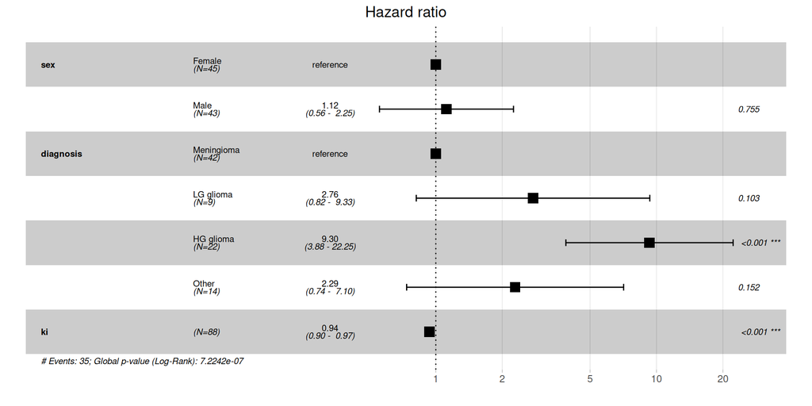

## Cox proportional hazards model

*Model output*

Cox regression output includes several useful tests.

- **Likelihood Ratio Test (LRT)**
  - Compares the log-likelihood of:
    - A null model (no covariates)
    - A full model (with covariates)
  - Tests whether the covariates improves model fit
- **Wald test**
  - Individual Wald tests assess whether each coefficient is significantly different from 0
  - A global Wald test assesses whether all coefficients are 0 simultaneously
- **Score test**
  - Based on **expected vs. observed** events
  - In simple group-comparison settings, it corresponds to the log-rank test

## Cox proportional hazards model

*Concordance*

The **concordance index** measures how well the model predicts the order of events.

- **C-index = 0.5** → No better than random guessing
- **C-index = 1** → Perfect prediction of event order

**Example:**

- Concordance = **0.782**
- The model correctly orders event times in 78.2% of comparable pairs

## Cox proportional hazards model

*Time-dependent covariates*

So far, predictors have been fixed over time.

But some predictors may **change during follow-up**, for example:

- blood pressure
- treatment status
- disease severity

The Cox model can be extended to time-dependent covariates:

$$h(t|\boldsymbol{x}(t)) = h_0(t)\exp(\boldsymbol{\beta}^T\boldsymbol{x}(t))$$

In practice, one individual may contribute several rows, one for each interval where the covariates are constant.

## Competing risks

A **competing risk** is an event that prevents the event of interest from occurring.

**Why it matters:**

- standard Cox models typically focus on one event type at a time
- ignoring competing risks can overestimate the cumulative probability of the event of interest

Useful tools:

- **Cumulative incidence function (CIF)**  
  estimates the probability of a specific event by time $t$, accounting for competing risks
- **Gray’s test**  
  tests whether CIFs differ between groups
- **Fine and Gray model**  
  models the effect of covariates on the **subdistribution hazard**, and is used when interest lies in prediction or comparison of cumulative incidence

## Lab

In the lab there are examples of:

- constructing Kaplan-Meier curves
- comparing survival curves with the log-rank test
- fitting Cox proportional hazards models
- interpreting model output
- handling time-dependent covariates
- dealing with competing risks